# Homework 6

Connecticut Real Estate Sales Data

Joseph Farrell  
2022-04-27

## Load Libraries

```r
library(readr)
library(tidyverse)
library(dplyr)
library(mosaic)
library(ggplot2)
library(lubridate)
library(xts)
library(formattable)
library(forecast)
library(kableExtra)
library(plotly)
library(gapminder)
library(gganimate)
library(gifski)
library(png)
library(ggfortify)
library(tidyquant)
library(tidycensus)
library(ggstatsplot)
library(scales)
library(feasts)
library(tsibble)
```

## Introduction

The following is an analysis of Connecticut real estate sales data. The data set used in this analysis contains 930,621 observations (transactions) and contains data from 2005-2020. There are 14 variables in the original data set. Not all observations and variables will be pertinent to answering the research questions and will be subsequently filtered out. The research questions this analysis will attempt to answer or at least provide insights into answering are:

- Where in Connecticut are properties values the highest?
- Are property values in the Connecticut increasing or decreasing?
- Where are property values increasing/decreasing?
- Is the price behavior different for different property types?

## Read in Data

I will read in two data sets that will be joined and used for the analysis.

- **Connecticut** contains Connecticut real estate sales data from 2005-2020.
- **County_town** contains a list of Connecticut counties and the towns that are in each county. This latter data set will be useful for grouping in the analysis. As will be displayed later, many of the towns contain limited observations so an alternative grouping option will be useful.

```r
connecticut <- read_csv("/Users/nelsonfarrell/Downloads/Real_Estate_Sales_2001-2019_GL.csv")
county_town <- read_csv(("/Users/nelsonfarrell/Documents/501 Stats/Connecticut County:Towns.csv"))
county_town <- county_town %>%
  select("subregion",
         "town")
```

## Data Cleaning

**Rename “Town” variable “town” to join datasets**

```r
connecticut <- rename(connecticut, "town" = "Town")
```

Here I am changing the name of the “Town” variable in the Connecticut data set so it will match the “town” variable in the county_town data set.

**Join datasets**

```r
connecticut <-
  left_join(connecticut, county_town, by = "town")
```

Here am joining the data sets, this will be useful when grouping in the analysis.

**Remove unnecassary columns**

```r
connecticut <- select(connecticut,
                      "List Year",
                      "Date Recorded",
                      "town",
                      "Sale Amount",
                      "Residential Type",
                      "subregion")
```

Here I have removed the columns “Serial number”, “Non Use Code”, “Assessor Remarks”, “Sales Ratio”, “Property Type”, “Location”, “Assessed Value”, and “OPM Remarks”

- These removed columns do not appear to be essential to the current analysis

**Remove NAs from “Residential Type”**

```r
connecticut <- connecticut %>%
  na.omit(`Residential Type`)
```

The NAs removed here are simply nonresidential properties, which will not be part of the analysis.

**Rename columns without spaces and for clarity**

```r
connecticut <- rename(connecticut,
                      "list_year" = "List Year",
                      "sale_date" = "Date Recorded",
                      "sale_price" = "Sale Amount",
                      "property_type" = "Residential Type",
                      "county" = "subregion")
```

In addition to removing spaces from the column names, I have renamed residential type “property type” as there are no longer non-residential properties, this naming scheme is more intuitive.

**Convert “sale_date” from character to date and create new column “sale_year”**

```r
connecticut$sale_date <- as_date(connecticut$sale_date,
                                 format = "%m/%d/%Y")
connecticut <- connecticut %>%
  mutate(sale_year = year(sale_date))
```

**Remove all observations prior to 2007**

```r
connecticut <- connecticut %>%
  filter(sale_year > 2006)
```

The data prior to and including 2006 is very limited. As a result, I have removed all observations prior to 2007.

- See appendix **Part A** for justification.

**Remove top and bottom 2.5% of “sale_price”**

```r
connecticut <- connecticut %>%
  filter(sale_price < quantile(connecticut$sale_price, .975) &
           sale_price > quantile(connecticut$sale_price, .025))
```

The data was heavily skewed to the right, with extreme outliers in the right direction which impacted the measure of central tendency (mean). After trimming the data it is still skewed to the right but not as heavily.

- See appendix **Part B** for justification.

**View data set following cleaning**

```r
str(connecticut)
```

```
tibble [509,278 × 7] (S3: tbl_df/tbl/data.frame)
 $ list_year    : num [1:509278] 2014 2014 2014 2014 2014 ...
 $ sale_date    : Date[1:509278], format: "2015-08-06" ...
 $ town         : chr [1:509278] "Stamford" "New Haven" "Ridgefield" "New Britain" ...
 $ sale_price   : num [1:509278] 850000 149900 570000 261000 250000 ...
 $ property_type: chr [1:509278] "Single Family" "Single Family" "Single Family" "Condo" ...
 $ county       : chr [1:509278] "fairfield" "new haven" "fairfield" "hartford" ...
 $ sale_year    : num [1:509278] 2015 2015 2015 2015 2015 ...
 - attr(*, "na.action")= 'omit' Named int [1:382446] 13 27 28 33 53 78 83 105 127 132 ...
  ..- attr(*, "names")= chr [1:382446] "13" "27" "28" "33" ...
```

After cleaning the data set we are left with seven variables (columns):

- **list_year**: This is a numeric variable. This is the year that the property was listed (i.e., when the property was put up for sale).
- **sale_date**: This is a date variable. This is the date that the property was actually sold.
- **town**: This is a nominal character variable. This is the town where the property is located.
- **county**: This is a nominal character variable. This is the county where the property is located.
- **sale_price**: This is a numeric variable. This is the price that property sold for.
- **property_type**: This is nominal character variable. This is the type of property (i.e., condo, single family, two family, etc.)
- **sale_year**: This is a numeric variable. This is the year the property was sold.

Now that we have data cleaned we take a look at some statewide data so we can get an idea of the general state of the real estate market in Connecticut.

## Statewide Data

### Line Graph: Statewide mean

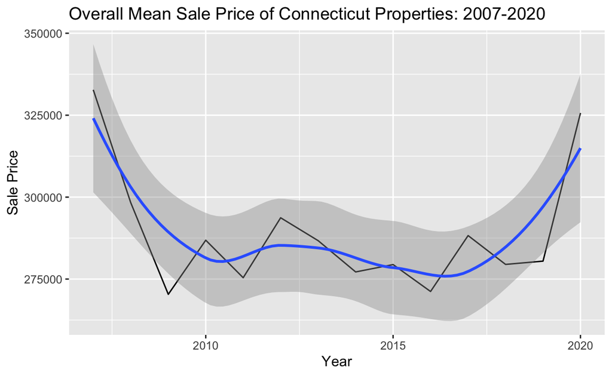

```r
connecticut %>%
  group_by(year = lubridate::floor_date(sale_date, "year")) %>%
  summarize(mean_year = mean(sale_price)) %>%
  ggplot(aes(x = year, y = mean_year)) +
  geom_line(aes()) +
  geom_smooth() +
  ggtitle("Overall Mean Sale Price of Connecticut Properties: 2007-2020") +
  ylab("Sale Price") +
  xlab("Year") +
  theme_update()
```

Here we can observe the behavior of the overall mean sale price of properties in Connecticut from 2007 to 2020. As expected the mean price decreased sharply following the 2008 financial crisis and appears to have bottomed out and stabilized around 2010. From 2010 to 2019 there does not appear to be a lot change in the overall mean sale price.

### Map Visualization: Geom_polygon: Statewide Mean

**Read in map data**

```r
con_map <- map_data("county",
         "connecticut")
```

This data set contains latitude and longitude data that can be used to make a map visualization.

**Rename “subregion” “county” to join “con_map” with “connecticut”**

```r
con_map <- rename(con_map,
                  "county" = "subregion")
```

The “subregion” in the “con_map” data set is Connecticut counties so I will rename the variable so I can join it with the sales data.

**Create object “map_vis”: grouping by county and creating a “county_mean” column**

```r
map_vis <- connecticut %>%
  group_by(county) %>%
  summarize(county_mean = mean(sale_price))
```

This object contains the mean sale price of each county in Connecticut and will be joined the map data to display the mean sale price on a map.

**Join “mapping” object with “con_map” data**

```r
map_vis <- inner_join(map_vis,
                      con_map,
                      by = "county")
```

This object will be used to create a map visualization displaying county mean sale price.

**Create object to use when labeling the counties on the map**

```r
county_names <- aggregate(cbind(long,
                                lat) ~ county,
                          data=map_vis,
                    FUN=function(x)mean(range(x)))
```

This creates an object that will center the name of the county inside that county on the map visualization.

**Create map of Connecticut counties displaying the mean sale price of residential properties**

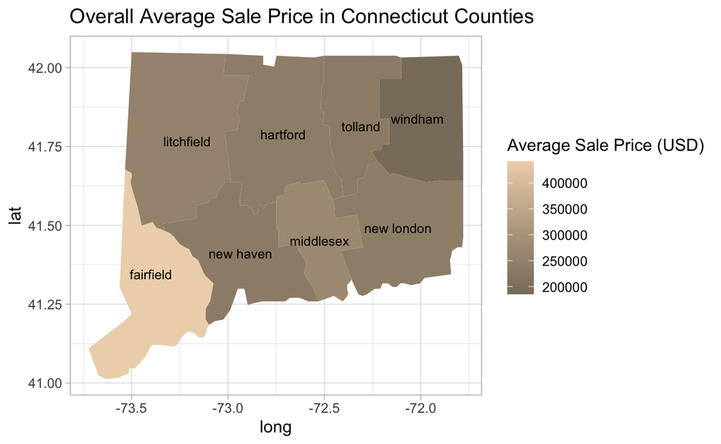

```r
ggplot(map_vis,
       aes(x = long,
           y = lat)) +
  geom_polygon(aes(fill = county_mean,
                   group = county)) +
  geom_text(data = county_names,
            aes(long,
                lat,
                label = county),
                size =3) +
  scale_fill_gradient(low = "bisque4",
                      high = "bisque2",
                      name = "Average Sale Price (USD)") +
  ggtitle("Overall Average Sale Price in Connecticut Counties") +
  theme_light()
```

Here we can get a visualization of where in Connecticut (grouped by county) property values are the highest. Not surprisingly, the area closest to New York City appears to have the highest property value.

- The previous two graphics display all the property types combined which may not generate the most reliable results. For the rest of the analysis, like property types will be compared.

### Visualizations: Grouped by Property Type

[figure not shown]

```r
mean_property_type <-connecticut %>%
  group_by(year = lubridate::floor_date(sale_date, "year"),
           property_type) %>%
  summarize(mean = mean(sale_price))

mean_property_type <-ggplot(mean_property_type,
              aes(year,
                  mean,
                  color = property_type)) +
  geom_line() +
  transition_reveal(year) +
  labs(title = "Mean Sale Price: 2007-2020",
       subtitle = "Grouped By Property Type",
       x = "Year",
       y = "Price ($)") +
  guides(color = guide_legend(title = "Property Type"))


animate(mean_property_type)
```

**Scatterplot of yearly mean sale price for each “Property Type”**

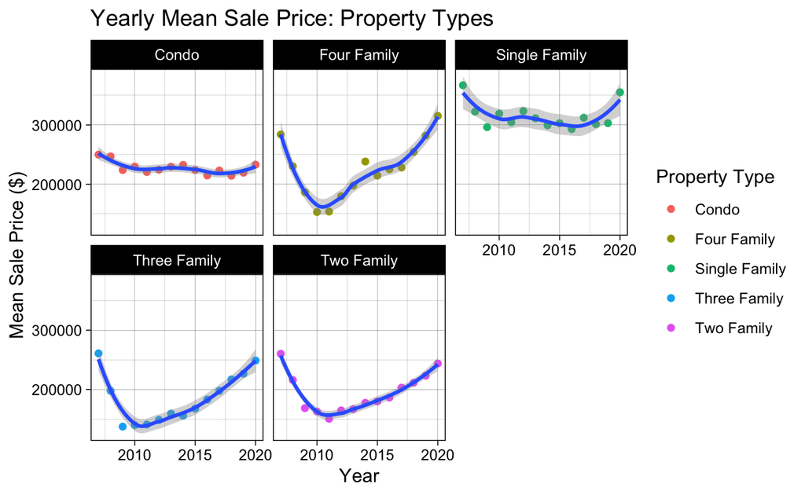

```r
options(scipen = 999) # remove scientific notation
connecticut %>%
  group_by(property_type,
           year = lubridate::floor_date(sale_date, "year")) %>%
  summarize(mean_year_type = mean(sale_price)) %>%
  ggplot(aes(x = year,
             y = mean_year_type,
             group = property_type)) +
  geom_point((aes(color = property_type))) +
  geom_smooth() +
  ggtitle("Yearly Mean Sale Price: Property Types") +
  ylab("Mean Sale Price ($)") +
  xlab("Year") +
  theme_linedraw() +
  facet_wrap(vars(property_type)) +
  guides(color = guide_legend(title = "Property Type"))
```

- Overall, the graphic demonstrates that the behavior of the mean sale price is different for different property types.
- The graphic shows that multi-unit properties appear to have started increasing in value earlier than single family properties (i.e. condo and single family).
- The mean sale price of condos has been largely constant.
- Single family properties appear to have been constant right up until 2020 when they experienced a rapid increase. This aligns with the well documented housing boom that resulted from the Covid-19 pandemic.
- Four family properties appear to be increasing the fastest, but also appear to be the most volatile and potentially risky.
- Two and three family properties appear to have started increasing directly after the crash of 2008 and appear to have been steadily increasing ever since.
- Before we can continue the analysis we will have to examine the counts of the different property types.

## Counts: Property Types: Statewide & County

Here we will examine the counts of the different property types in our data set. We will also look at the counts in each specific county and later in each town.

**View Counts of Property types**

```r
connecticut %>%
  count(property_type) %>%
  mutate("Proportion"= percent(n/sum(n))) %>%
  rename("Property Type" = "property_type") %>%
  rename("Number of Properties Sold" = "n") %>%
  kbl() %>%
  kable_material(c("striped",
                   "hover"))
```

| Property Type | Number of Properties Sold | Proportion |
| --- | --- | --- |
| Condo | 98463 | 19.3% |
| Four Family | 1985 | 0.4% |
| Single Family | 373121 | 73.3% |
| Three Family | 11262 | 2.2% |
| Two Family | 24447 | 4.8% |

Here we can see how many observations there are for each “property type.”

## Delta mean: Counties

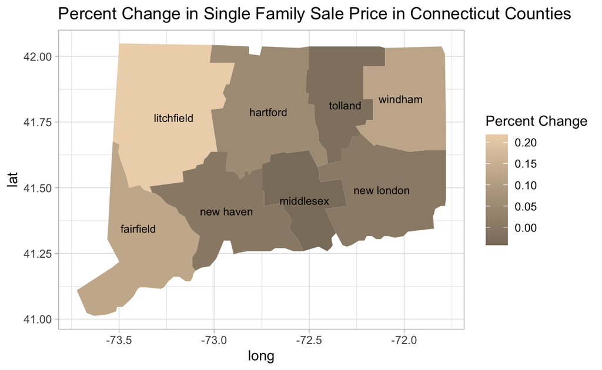

```r
connecticut %>%
  group_by(county,
           property_type,
           sale_year) %>%
  summarize(mean_sale_price = mean(sale_price)) %>%
  select(county,
         property_type,
         sale_year,
         mean_sale_price) %>%
  filter(sale_year == "2008" |
         sale_year =="2020") %>%
  filter(property_type == "Single Family") %>%
  pivot_wider(names_from = sale_year,
              values_from = mean_sale_price) %>%
  mutate(delta_mean = (`2020` - `2008`)) %>%
  mutate(delta_mean_percent = (delta_mean/`2008`)) %>%
  inner_join(con_map,
             by = "county") %>%
  ggplot(aes(x = long,
           y = lat)) +
  geom_polygon(aes(fill = delta_mean_percent,
                   group = county)) +
  geom_text(data = county_names,
            aes(long,
                lat,
                label = county),
                size =3) +
  scale_fill_gradient(low = "bisque4",
                      high = "bisque2",
                      name = "Percent Change") +
  ggtitle("Percent Change in Single Family Sale Price in Connecticut Counties") +
  theme_light()
```

```r
connecticut %>%
  group_by(county,
           property_type,
           sale_year) %>%
  summarize(mean_sale_price = mean(sale_price)) %>%
  select(county,
         property_type,
         sale_year,
         mean_sale_price) %>%
  filter(sale_year == "2008" |
         sale_year =="2020") %>%
  filter(property_type == "Single Family") %>%
  pivot_wider(names_from = sale_year,
              values_from = mean_sale_price) %>%
  mutate(delta_mean_ID = (`2020` - `2008`)) %>%
  mutate(delta_mean_percent = percent(delta_mean_ID/`2008`)) %>%
  mutate(across(contains("ID"), round, 2)) %>%
  arrange(desc(delta_mean_percent)) %>%
  rename("County" = "county",
         "Mean 2008" = "2008",
         "Mean 2020" = "2020",
         "Change in Mean ($)" = "delta_mean_ID",
         "Change in Mean (%)" = "delta_mean_percent") %>%
  mutate(County = str_to_title(County)) %>%
  formattable(align = c("l",
                        "c",
                        "r"),
              list(`Mean 2020` = FALSE,
                   `Mean 2008` = FALSE,
                   `property_type` = FALSE,
                   `Change in Mean (%)` = formatter("span",
                 style = ~ formattable::style(color = ifelse(`Change in Mean (%)` < 0,
                                                "firebrick",
                                                "forestgreen")),
                 ~ icontext(sapply(`Change in Mean (%)`,
                                   function(x) if (x < 0) "arrow-down" else if (x > 0) "arrow-up"),
                            `Change in Mean (%)`))))
```

| County | Change in Mean ($) | Change in Mean (%) |
| --- | --- | --- |
| Hartford | 13627.15 | 5% |
| Litchfield | 64267.71 | 22% |
| Fairfield | 64666.65 | 13% |
| Windham | 25014.99 | 12% |
| New Haven | -219.55 | 0% |
| New London | 397.25 | 0% |
| Middlesex | -13839.78 | -4% |
| Tolland | -6941.51 | -3% |

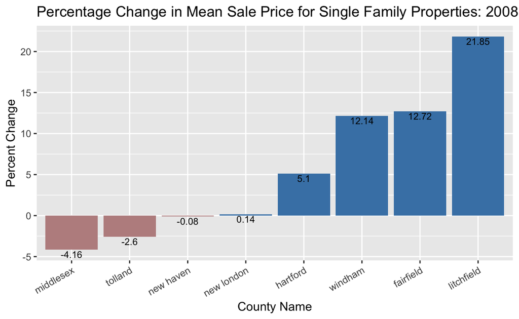

```r
connecticut %>%
  group_by(county,
           property_type,
           sale_year) %>%
  summarize(mean_sale_price = mean(sale_price)) %>%
  select(county,
         property_type,
         sale_year,
         mean_sale_price) %>%
  filter(sale_year == "2008" | sale_year =="2020") %>%
  filter(property_type == "Single Family") %>%
  pivot_wider(names_from = sale_year, values_from = mean_sale_price) %>%
  mutate(delta_mean_ID = (`2020` - `2008`)) %>%
  mutate(delta_mean_percent = (delta_mean_ID/`2008`*100)) %>%
  mutate(across(contains("percent"), round, 2)) %>%
  mutate(Color = ifelse(delta_mean_percent < 0, "rosybrown","steelblue")) %>%
  ggplot(aes(x = reorder(county, delta_mean_percent),
             y = delta_mean_percent,
             fill = Color)) +
  geom_col()+
  geom_text(aes(label = delta_mean_percent,
                vjust = 1.2),
                size = 3) +
  labs(title = "Percentage Change in Mean Sale Price for Single Family Properties: 2008 to 2020",
                x = "County Name",
                y = "Percent Change") +
  theme(axis.text.x = element_text(angle = 30,
                                   hjust = 1)) +
  scale_fill_identity(guide = "none")
```

**Create line graph of the mean sale price of single family properties in different counties**

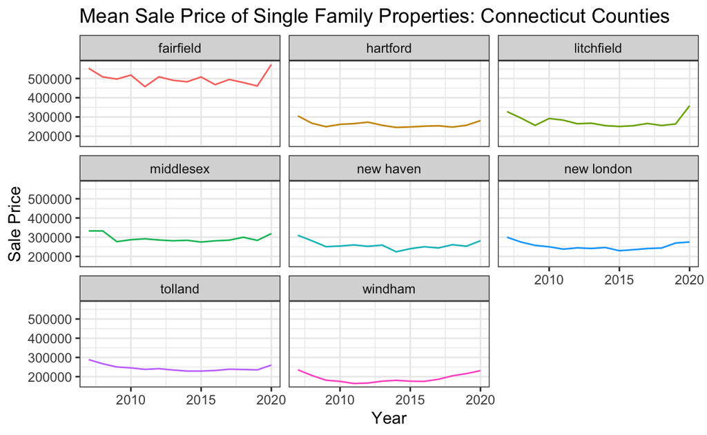

```r
connecticut %>%
  group_by(county,
           property_type,
           year = lubridate::floor_date(sale_date, "year")) %>%
  summarize(mean_year = mean(sale_price)) %>%
  filter(property_type == "Single Family") %>%
  ggplot(aes(x = year,
             y = mean_year)) +
  geom_line(aes(color = county)) +
  ggtitle("Mean Sale Price of Single Family Properties: Connecticut Counties") +
  ylab("Sale Price") +
  xlab("Year") +
  theme_bw() +
  facet_wrap(vars(county)) +
  guides(color = "none")
```

- These graphics display the behavior of the mean sale price of single family properties in the eight Connecticut counties over the ~15 years of the data.
- We can see clearly that property values are the highest in Fairfield County, but we can also see that property values are  
  increasing in a number of Connecticut counties, this increase appears most pronounced in Fairfield and Litchfield. Windham County, which shows a 12.14% increase appears graphically to have started increasing prior to 2019, and has been increasing more steadily.

Next, we will shift to focus to potential drivers of sale price

## What is driving price?

### Number of Properties Sold

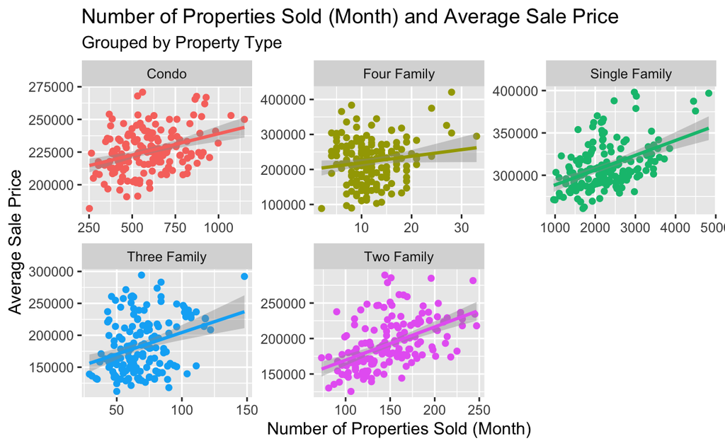

```r
connecticut %>%
  group_by(month = floor_date(sale_date,
                              "month"),
           property_type) %>%
  summarize(mean_price = mean(sale_price),
            count = count(month)) %>%
  ggplot(aes(x = count,
             y = mean_price,
             color = property_type)) +
  geom_point() +
  geom_smooth(method = "lm") +
  ggtitle("Number of Properties Sold (Month) and Average Sale Price",
          subtitle = "Grouped by Property Type") +
  xlab("Number of Properties Sold (Month)") +
  ylab("Average Sale Price") +
  facet_wrap(vars(property_type),
             scales = "free") +
  guides(color = "none")
```

- Here we are looking the relationship between the number of properties sold and how it impacts sales price. Number of properties sold is the x variable and mean sale price is the y variable. Here we are aggregating by month.
- This graphic demonstrates that there does appear to be a least a slight positive linear relationship between the number of properties sold in a given month and the average sale price.

Next we will take a closer look at this relationship as it relates to Single Family properties.

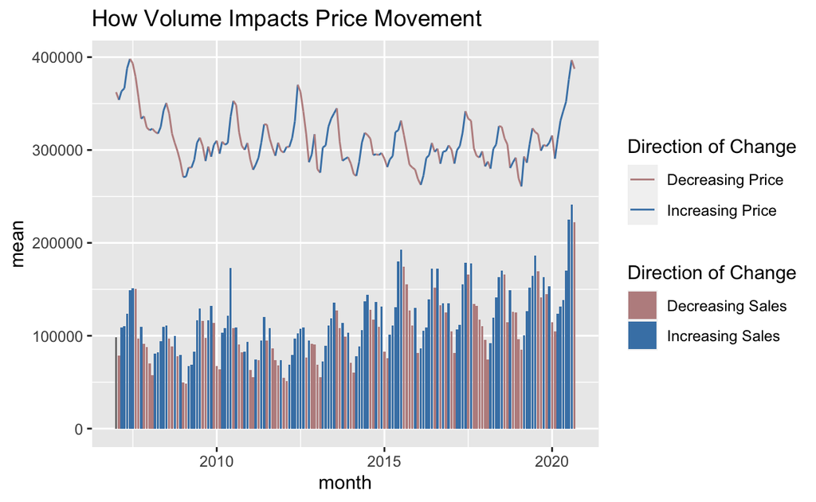

```r
connecticut %>%
  group_by(property_type,
           month = floor_date(sale_date,
                              "month")) %>%
  filter(property_type == "Single Family") %>%
  summarize(mean = mean(sale_price),
            properties_sold = count(month)) %>%
  mutate(previous_mean = lag(mean)) %>%
  mutate(previous_month = lag(month)) %>%
  mutate(Direction = ifelse(properties_sold < lag(properties_sold),
                            "Decreasing Sales",
                            "Increasing Sales")) %>%
  mutate(Direction2 = ifelse(mean < lag(mean),
                             "Decreasing Price",
                             "Increasing Price")) %>%
  ggplot(aes(month, mean,
              xend = previous_month,
              yend = previous_mean)) +
  geom_segment(aes(color = Direction2)) +
  scale_color_manual("Direction of Change",
                     values = c("Decreasing Price" = "rosybrown",
                                "Increasing Price" = "steelblue")) +
  geom_col(aes(x = month,
               y = properties_sold*50,
               fill = Direction)) +
  scale_fill_manual("Direction of Change",
                    values = c("Decreasing Sales" = "rosybrown",
                               "Increasing Sales" = "steelblue")) +
  ggtitle("How Volume Impacts Price Movement")
```